# Linear Regression (Frequentist and Bayesian) - 2025-05-06

Prof. Gwen Eadie

2025-05-06

## Fitting a simple regression line to mock data (frequentist approach)

This exercise follows section 6.2 in Gelman, Hill, and Vehtari (2021).

1. Simulate 20 fake data points from the model
   $$y_i = a +bx_i + \epsilon_i$$
   where there is one predictor (covariate) that takes on values between 1 and 20, and where the intercept is 0.2 and the slope is 0.3, and
   $$\epsilon_i \sim N(0, \sigma=0.5)$$

```r
# write code and a function to simulate y values here.
n=20
x = 1:n
simfunc = function(a, b, sigma, x){ a + b*x + rnorm(n, mean = 0, sd = sigma) }

mya = 0.2
myb = 0.3
mysigma = 0.5

y = simfunc(a=mya, b=myb, sigma = mysigma, x=x)
```

2. Fit a linear regression model to these fake data. You will need to create a `data.frame` containing both the predictor and the outcome. Use the function `lm` to fit the simple linear regression.

```r
# create data frame with covariate and outcome in columns
fakedata = data.frame(x, y)

# you should use the lm function and assign the results to a new object
lmfit = lm(y ~ x, data = fakedata)
```

3. Now display the results using `print`. What does print show you?

```r
print(lmfit)
```

```
##
## Call:
## lm(formula = y ~ x, data = fakedata)
##
## Coefficients:
## (Intercept)            x
##     -0.1005       0.3167
```

4. Display results using `summary`, which gives a little more information (e.g., the standard error of each estimate)

```r
summary(lmfit)
```

```
##
## Call:
## lm(formula = y ~ x, data = fakedata)
##
## Residuals:
##     Min      1Q  Median      3Q     Max
## -0.9391 -0.3134 -0.1139  0.4123  1.1747
##
## Coefficients:
##             Estimate Std. Error t value Pr(>|t|)
## (Intercept) -0.10055    0.23729  -0.424    0.677
## x            0.31669    0.01981  15.987 4.42e-12 ***
## ---
## Signif. codes:  0 '***' 0.001 '**' 0.01 '*' 0.05 '.' 0.1 ' ' 1
##
## Residual standard error: 0.5108 on 18 degrees of freedom
## Multiple R-squared:  0.9342, Adjusted R-squared:  0.9306
## F-statistic: 255.6 on 1 and 18 DF,  p-value: 4.417e-12
```

5. Plot the data, regression line, and confidence bands

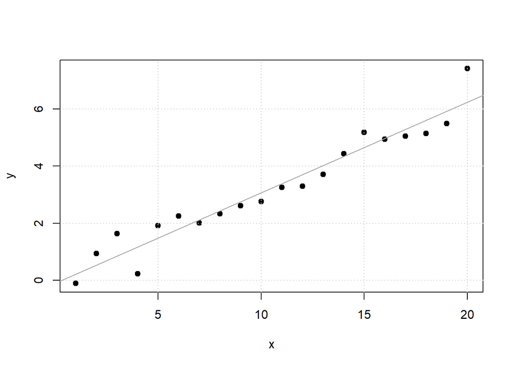

```r
# simple plot without confidence bands
plot(fakedata$x, fakedata$y, pch=19, xlab="x", ylab="y")
grid()
abline(lmfit, col="darkgrey")
```

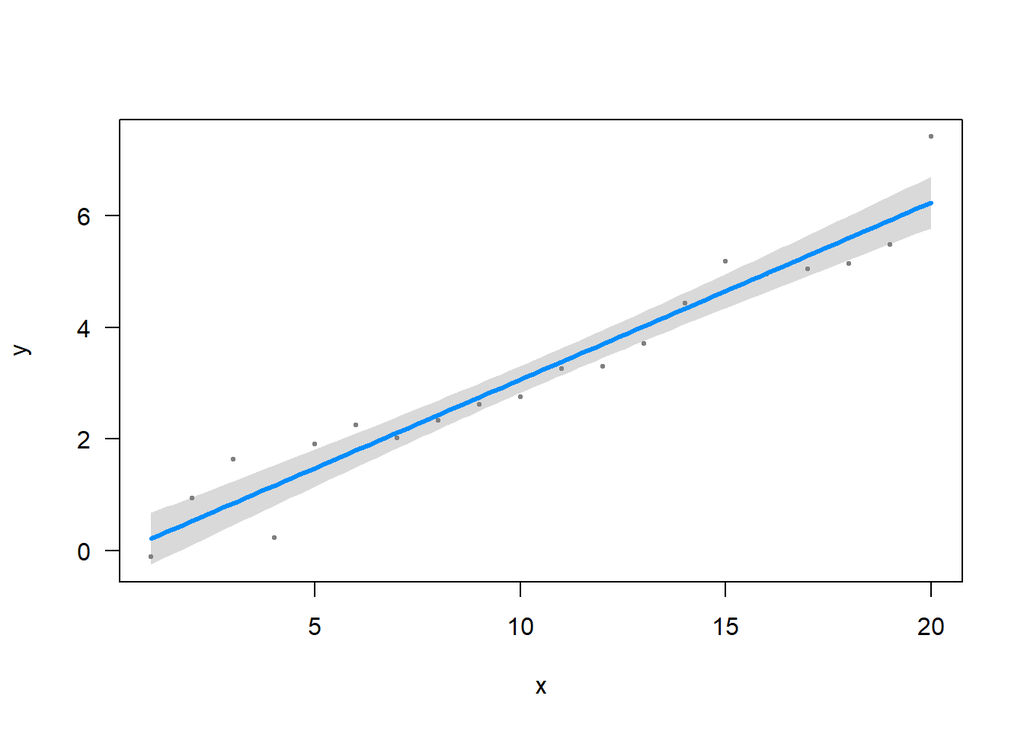

```r
# can use the visreg package to easily make fit line with confidence bands
library(visreg)
visreg(lmfit)
```

## Inferring the parameters for a line (Bayesian approach)

Using the same mock data, infer the parameters of the intercept and slope.

```r
# load packages
library(ggplot2)
library(tidyverse)
library(tidybayes)
library(brms)
```

```r
#bayesfit <- stan_lm(y ~ x, data = fakedata, prior=NULL)
# use Bayesian Regression Model (brm) function from brms package
bayesfit <- brm(y ~ x, data = fakedata)
```

2. Look at the chains and summary of the output of the inferred posterior distribution

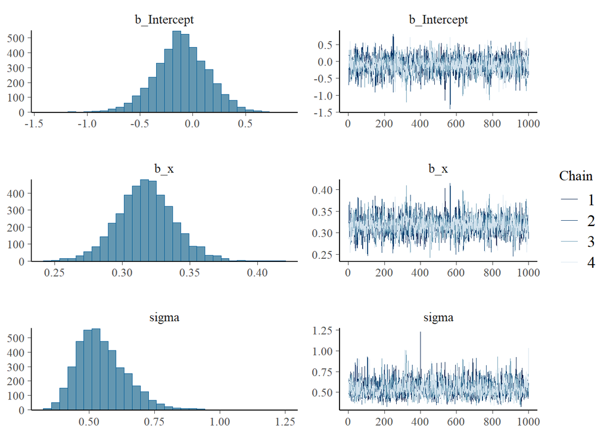

```r
# plot the Markov chains and marginal distribution of the draws
plot(bayesfit)
```

```r
# get the summary output
summary(bayesfit)
```

```
##  Family: gaussian
##   Links: mu = identity; sigma = identity
## Formula: y ~ x
##    Data: fakedata (Number of observations: 20)
##   Draws: 4 chains, each with iter = 2000; warmup = 1000; thin = 1;
##          total post-warmup draws = 4000
##
## Regression Coefficients:
##           Estimate Est.Error l-95% CI u-95% CI Rhat Bulk_ESS Tail_ESS
## Intercept    -0.11      0.25    -0.62     0.38 1.00     3350     2406
## x             0.32      0.02     0.28     0.36 1.00     3366     2242
##
## Further Distributional Parameters:
##       Estimate Est.Error l-95% CI u-95% CI Rhat Bulk_ESS Tail_ESS
## sigma     0.55      0.10     0.40     0.77 1.00     2893     2636
##
## Draws were sampled using sampling(NUTS). For each parameter, Bulk_ESS
## and Tail_ESS are effective sample size measures, and Rhat is the potential
## scale reduction factor on split chains (at convergence, Rhat = 1).
```

3. Plot the inferred relationship using the posterior distribution

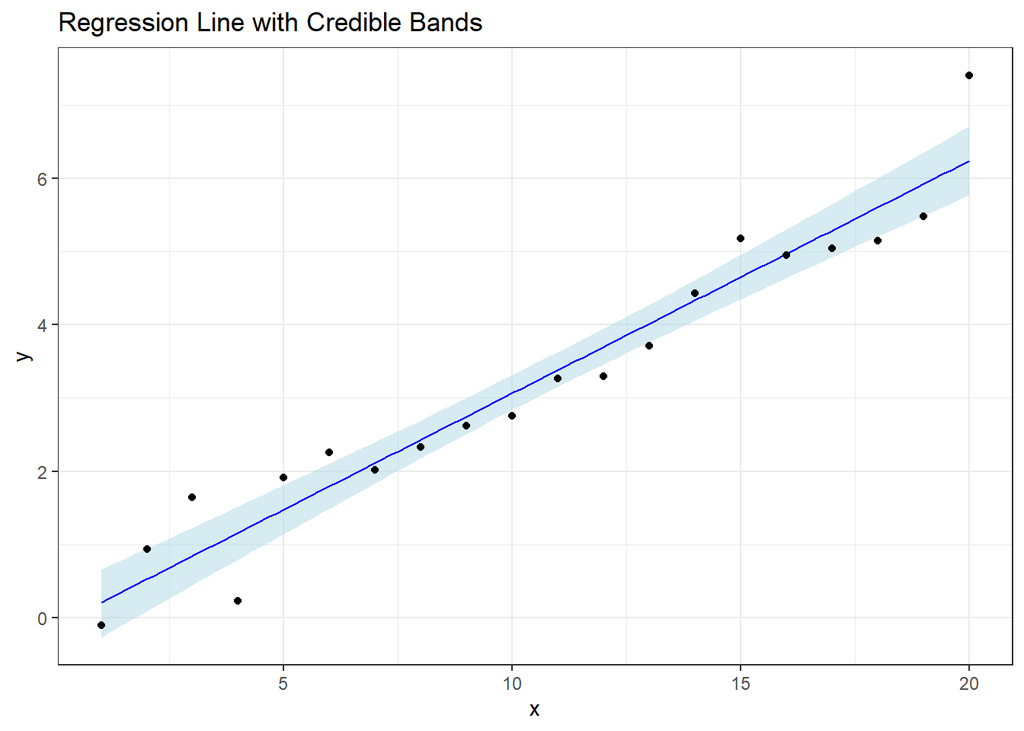

```r
# Create a new data frame that will be used to generate predictions given the (Bayesian) regression prediction of y at a bunch x's
new_data <- data.frame(x = seq(min(fakedata$x), max(fakedata$x), length.out = 100))

# Get fitted values for the new_data object
fitted_values <- fitted(bayesfit, newdata = new_data)

# Use the posterior draws and new_data object to calculate credible intervals
posterior_draws <- posterior_epred(bayesfit, newdata = new_data, draws = 1000)

# Calculate the credible interval (e.g., 95% CI):
credible_interval <- apply(posterior_draws, 2, function(x) quantile(x, probs = c(0.025, 0.975)))


# Now plot the line and credible intervals using the ggplot2 package
ggplot(new_data, aes(x = x)) +
    geom_ribbon(aes(ymin = credible_interval[1,], ymax = credible_interval[2,]), fill = "lightblue", alpha = 0.5) +
    geom_line(aes(y = fitted_values[,1]), color = "blue") +
    geom_point(data = fakedata, aes(y = y)) +
    labs(title = "Regression Line with Credible Bands", x = "x", y = "y") +
    theme_bw()
```